# Comcast Telecom Complaints Project

Ghadi K

11-13-2020

# Dataset

In this project, I worked on Comcast Telecom Complaints Dataset where Comcast is a company notorious for terrible customer service and despite repeated promises to improve, they continue to fall short.

In the beginning, I start by clean the data and make sure there is to NA values and every column is in the right format for my analysis. Also, fix the column name for the Ticket column. This how the data look like after :

|  | Ticket | Customer.Complaint | Date | Time | Received.Via | City | State | Zip.code | Status | Filing.on.Behalf.of.Someone |
| --- | --- | --- | --- | --- | --- | --- | --- | --- | --- | --- |
| 1 | 250635 | Comcast Cable Internet Speeds | 2015-04-22 | 3:53:50 PM | Customer Care Call | Abingdon | Maryland | 21009 | Closed | No |
| 2 | 223441 | Payment disappear - service got disconnected | 2015-08-04 | 10:22:56 AM | Internet | Acworth | Georgia | 30102 | Closed | No |
| 3 | 242732 | Speed and Service | 2015-04-18 | 9:55:47 AM | Internet | Acworth | Georgia | 30101 | Closed | Yes |
| 4 | 277946 | Comcast Imposed a New Usage Cap of 300GB that punishes streaming. | 2015-07-05 | 11:59:35 AM | Internet | Acworth | Georgia | 30101 | Open | Yes |
| 5 | 307175 | Comcast not working and no service to boot | 2015-05-26 | 1:25:26 PM | Internet | Acworth | Georgia | 30101 | Solved | No |
| 6 | 338519 | ISP Charging for arbitrary data limits with overage fees | 2015-12-06 | 9:59:40 PM | Internet | Acworth | Georgia | 30101 | Solved | No |

# Data Visualization

Here I want to provide the trend chart for the number of complaints at monthly and daily granularity levels. This can help determine at which day or month the complaints increase so we can investigate further for the reason of that.

## No. of Complaints at Monthly Level

Here we can see that in June the number of complaints increases and June has the highest number of complaints during the entire year. And before this increase, there has been increasing in the number of complaints during April and May just before the increase in the number of complaints in June.

So we could say that problems were unsolved fully in April and May and that leads to the huge increase in June.

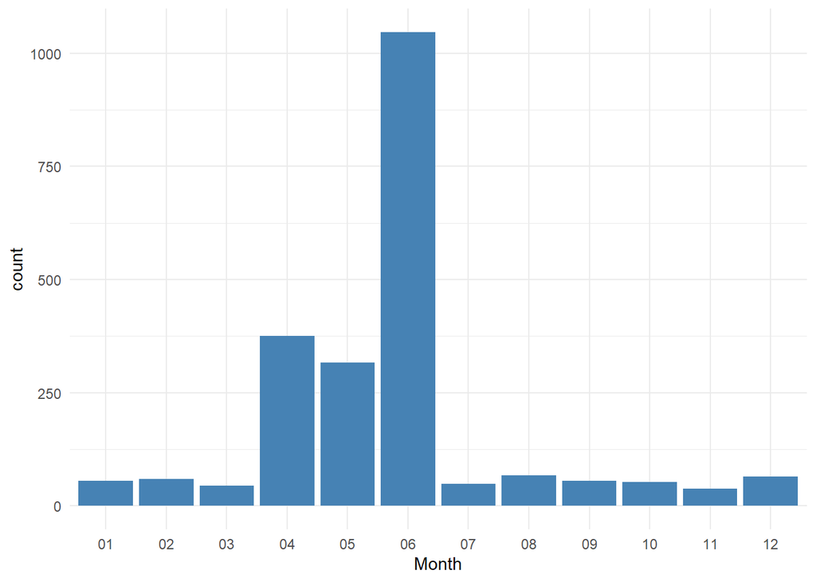

## No. of Complaints at Daily Level

Here we can see that someday don’t have any complaints and other day has a very high number of complaints and later we can use this information to see what was the common problem in day 6 for example.

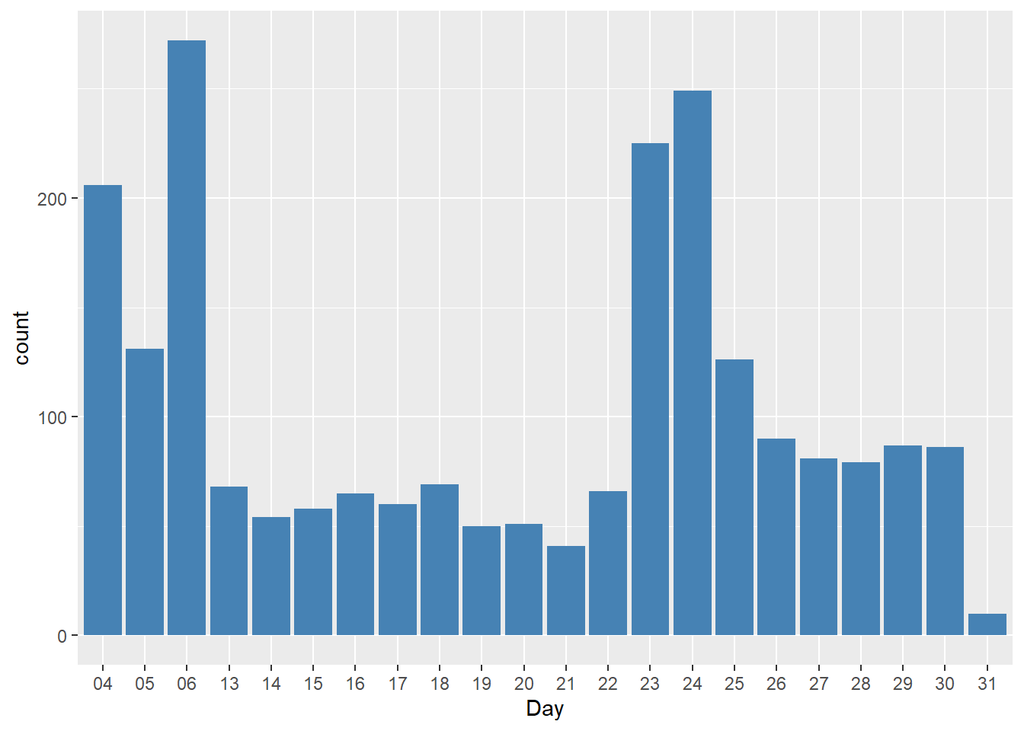